# RStudio projects

RStudio projects (.Rproj) are a handy solution to keep all the files related to a specific workflow, including

- **R scripts** (.R),
- **workspace** files (.RData),
- **history** files (.Rhistory),
- required **datasets**,
- etc.,

together in one working directory. RStudio projects, once opened, are automatically associated with the directory the .Rproj file is located in, thus rendering unnecessary the use of `setwd()`.

### Starting a new project

From inside RStudio, projects are easily initialized and associated with either

- a brand new working directory,
- an existing directory or
- a local copy of a version control repository (of which more later on)

by hitting the ‘New Project…’ button from the drop-down menu at the top-right corner.

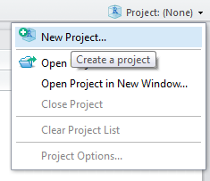

### Working with projects

Once created, RStudio automatically switches to the new project (not without asking if you’d like to safe your latest changes and workspace contents, of course). If you desire to work with an already existing project instead, you may simply open the referring .Rproj file either via the drop-down menu in the top- right corner, or just double-click it within your system’s file explorer. The following actions are taken when a project is opened inside RStudio (taken from https://support.rstudio.com/hc/en-us/articles/200526207-Using-Projects):

- A new R session (process) is started
- The .Rprofile file in the project’s main directory (if any) is sourced by R
- The .RData file in the project’s main directory is loaded (if project options indicate that it should be loaded).
- The .Rhistory file in the project’s main directory is loaded into the RStudio History pane (and used for Console Up/Down arrow command history).
- The current working directory is set to the project directory.
- Previously edited source documents are restored into editor tabs
- Other RStudio settings (e.g. active tabs, splitter positions, etc.) are restored to where they were the last time the project was closed.